# Project: Investigate The European soccer Database

- Introduction
- 0. Required modules and libraries
- 1. Data Wrangling
- 1.1. Aquire Data from DB
- 1.2. Discover Data
- 1.3. Clean Data
- 1.4. Restructure Data
- 2. Exploratory Data Analysis
- 2.1. What is the most team achieved victories?
- 2.1.1. Prepare Data Frame
- 2.1.2. Plot visualization
- 2.1.3. Interpret the findings
- 2.2. What team attributes lead the most teams to achieve those victories?
- 2.2.1. Prepare Data Frame
- 2.2.2. Plot visualization
- 2.2.3. Interpret the findings
- 2.2.4. Trends
- Conclusions

## Introduction

```
In this project, I am going to investigate and answer questions about The European soccer Database Which is a database contains data about The European Professional Football. It contains the data of 25k matches, 10k players, 11 European countries, and seasons from 2008 to 2016.
I am going to investigate it through analysis using Python and Pandas. I am going to assess, clean, group, and visualize data. then interpret my findings.

The Questions I am going to search for an answers are:

  1. What is the most team achieved victories?
  2. What team attributes lead to the most victories?
```

## 0. Required modules and libiraries

```python
import pandas as pd
import sqlite3 as sq
import numpy as np
import seaborn as sns; sns.set_theme(color_codes=True)
import matplotlib.pyplot as plt
%matplotlib inline
```

## 1. Data Wrangling

```
In this section, I am going to connect to the database, apply some pandas method to discover and understand the data,
describe the data, clean data by removing missing values or outliers, then restructing the data to be in a format which facilitate the analysis, and finally filtering the dataset and remove the data wouldn't help in my analysis or wouldn't be needed.
```

### 1.1. Aquire Data from DB

```python
#Connecting to Soccer Db

#Making connection object
conn = sq.connect('database.sqlite')
cur = conn.cursor()
```

```python
#testing the connection
for row in cur.execute("SELECT * FROM Country"):
    print(row)
```

```
(1, 'Belgium')
(1729, 'England')
(4769, 'France')
(7809, 'Germany')
(10257, 'Italy')
(13274, 'Netherlands')
(15722, 'Poland')
(17642, 'Portugal')
(19694, 'Scotland')
(21518, 'Spain')
(24558, 'Switzerland')
```

### 1.2. Discover Data

```python
#The database contains 7 tables
# making df for each table
#and see what the tables we are going to use in our analysis and exclude the rest

df_country = pd.read_sql_query("SELECT * FROM Country",conn)
df_league = pd.read_sql_query("SELECT * FROM League",conn)
df_match = pd.read_sql_query("SELECT * FROM Match",conn)
df_player = pd.read_sql_query("SELECT * FROM Player",conn)
df_player_attr = pd.read_sql_query("SELECT * FROM Player_Attributes",conn)
df_team = pd.read_sql_query("SELECT * FROM Team",conn)
df_team_attr = pd.read_sql_query("SELECT * FROM Team_Attributes",conn)
```

```python
#setting paramter for pandas table view
#to show all columns and row in dataframe
pd.set_option('display.max_rows', 500)
pd.set_option('display.max_columns', 500)
pd.set_option('display.width', 1000)
```

```python
#function to discover and understand data
def discover_data(dataframe):
    print("\t\t\t\t\t\t----Data Frame data-----\n")
    print("##Dataframe shape:\n{}\n".format(dataframe.shape))
    print("##Dataframe info:\n{}\n".format(dataframe.info))
    print("##Dataframe data types\n:{}\n".format(dataframe.dtypes))
    print("##Dataframe nan sum\n:{}\n".format(dataframe.isna().sum()))
    print("##Dataframe duplicates sum:{}\n".format(dataframe.duplicated().sum()))
    print("##The top 5 rows in The DataFrame:")
    return dataframe.head()
```

```python
discover_data(df_country)
```

```
						----Data Frame data-----

##Dataframe shape:
(11, 2)

##Dataframe info:
<bound method DataFrame.info of        id         name
0       1      Belgium
1    1729      England
2    4769       France
3    7809      Germany
4   10257        Italy
5   13274  Netherlands
6   15722       Poland
7   17642     Portugal
8   19694     Scotland
9   21518        Spain
10  24558  Switzerland>

##Dataframe data types
:id       int64
name    object
dtype: object

##Dataframe nan sum
:id      0
name    0
dtype: int64

##Dataframe duplicates sum:0

##The top 5 rows in The DataFrame:
```

|  | id | name |
| --- | --- | --- |
| 0 | 1 | Belgium |
| 1 | 1729 | England |
| 2 | 4769 | France |
| 3 | 7809 | Germany |
| 4 | 10257 | Italy |

#### Observation for country:

- No nan values
- No duplicates

```python
discover_data(df_league)
```

```
						----Data Frame data-----

##Dataframe shape:
(11, 3)

##Dataframe info:
<bound method DataFrame.info of        id  country_id                      name
0       1           1    Belgium Jupiler League
1    1729        1729    England Premier League
2    4769        4769            France Ligue 1
3    7809        7809     Germany 1. Bundesliga
4   10257       10257             Italy Serie A
5   13274       13274    Netherlands Eredivisie
6   15722       15722        Poland Ekstraklasa
7   17642       17642  Portugal Liga ZON Sagres
8   19694       19694   Scotland Premier League
9   21518       21518           Spain LIGA BBVA
10  24558       24558  Switzerland Super League>

##Dataframe data types
:id             int64
country_id     int64
name          object
dtype: object

##Dataframe nan sum
:id            0
country_id    0
name          0
dtype: int64

##Dataframe duplicates sum:0

##The top 5 rows in The DataFrame:
```

|  | id | country_id | name |
| --- | --- | --- | --- |
| 0 | 1 | 1 | Belgium Jupiler League |
| 1 | 1729 | 1729 | England Premier League |
| 2 | 4769 | 4769 | France Ligue 1 |
| 3 | 7809 | 7809 | Germany 1. Bundesliga |
| 4 | 10257 | 10257 | Italy Serie A |

#### Observation for league:

- No nan values
- No duplicates

```python
discover_data(df_match)
```

[output not shown]

[output cut: 247 more lines]

|  | id | country_id | league_id | season | stage | date | match_api_id | home_team_api_id | away_team_api_id | home_team_goal | away_team_goal | home_player_X1 | home_player_X2 | home_player_X3 | home_player_X4 | home_player_X5 | home_player_X6 | home_player_X7 | home_player_X8 | home_player_X9 | home_player_X10 | home_player_X11 | away_player_X1 | away_player_X2 | away_player_X3 | away_player_X4 | away_player_X5 | away_player_X6 | away_player_X7 | … |
| --- | --- | --- | --- | --- | --- | --- | --- | --- | --- | --- | --- | --- | --- | --- | --- | --- | --- | --- | --- | --- | --- | --- | --- | --- | --- | --- | --- | --- | --- | --- |
| 0 | 1 | 1 | 1 | 2008/2009 | 1 | 2008-08-17 00:00:00 | 492473 | 9987 | 9993 | 1 | 1 | NaN | NaN | NaN | NaN | NaN | NaN | NaN | NaN | NaN | NaN | NaN | NaN | NaN | NaN | NaN | NaN | NaN | NaN | … |
| 1 | 2 | 1 | 1 | 2008/2009 | 1 | 2008-08-16 00:00:00 | 492474 | 10000 | 9994 | 0 | 0 | NaN | NaN | NaN | NaN | NaN | NaN | NaN | NaN | NaN | NaN | NaN | NaN | NaN | NaN | NaN | NaN | NaN | NaN | … |
| 2 | 3 | 1 | 1 | 2008/2009 | 1 | 2008-08-16 00:00:00 | 492475 | 9984 | 8635 | 0 | 3 | NaN | NaN | NaN | NaN | NaN | NaN | NaN | NaN | NaN | NaN | NaN | NaN | NaN | NaN | NaN | NaN | NaN | NaN | … |
| 3 | 4 | 1 | 1 | 2008/2009 | 1 | 2008-08-17 00:00:00 | 492476 | 9991 | 9998 | 5 | 0 | NaN | NaN | NaN | NaN | NaN | NaN | NaN | NaN | NaN | NaN | NaN | NaN | NaN | NaN | NaN | NaN | NaN | NaN | … |
| 4 | 5 | 1 | 1 | 2008/2009 | 1 | 2008-08-16 00:00:00 | 492477 | 7947 | 9985 | 1 | 3 | NaN | NaN | NaN | NaN | NaN | NaN | NaN | NaN | NaN | NaN | NaN | NaN | NaN | NaN | NaN | NaN | NaN | NaN | … |

#### Observation for match:

- alot of nan values in columns: from "home_player_X1" to "BSA"
- No duplicates
- Date object is not converted to date time object

```python
discover_data(df_player)
```

```
						----Data Frame data-----

##Dataframe shape:
(11060, 7)

##Dataframe info:
<bound method DataFrame.info of           id  player_api_id          player_name  player_fifa_api_id             birthday  height  weight
0          1         505942   Aaron Appindangoye              218353  1992-02-29 00:00:00  182.88     187
1          2         155782      Aaron Cresswell              189615  1989-12-15 00:00:00  170.18     146
2          3         162549          Aaron Doran              186170  1991-05-13 00:00:00  170.18     163
3          4          30572        Aaron Galindo              140161  1982-05-08 00:00:00  182.88     198
4          5          23780         Aaron Hughes               17725  1979-11-08 00:00:00  182.88     154
...      ...            ...                  ...                 ...                  ...     ...     ...
11055  11071          26357       Zoumana Camara                2488  1979-04-03 00:00:00  182.88     168
11056  11072         111182         Zsolt Laczko              164680  1986-12-18 00:00:00  182.88     176
11057  11073          36491            Zsolt Low              111191  1979-04-29 00:00:00  180.34     154
11058  11074          35506  Zurab Khizanishvili               47058  1981-10-06 00:00:00  185.42     172
11059  11075          39902   Zvjezdan Misimovic              102359  1982-06-05 00:00:00  180.34     176

[11060 rows x 7 columns]>

##Dataframe data types
:id                      int64
player_api_id           int64
player_name            object
player_fifa_api_id      int64
birthday               object
height                float64
weight                  int64
dtype: object

##Dataframe nan sum
:id                    0
player_api_id         0
player_name           0
player_fifa_api_id    0
birthday              0
height                0
weight                0
dtype: int64

##Dataframe duplicates sum:0

##The top 5 rows in The DataFrame:
```

|  | id | player_api_id | player_name | player_fifa_api_id | birthday | height | weight |
| --- | --- | --- | --- | --- | --- | --- | --- |
| 0 | 1 | 505942 | Aaron Appindangoye | 218353 | 1992-02-29 00:00:00 | 182.88 | 187 |
| 1 | 2 | 155782 | Aaron Cresswell | 189615 | 1989-12-15 00:00:00 | 170.18 | 146 |
| 2 | 3 | 162549 | Aaron Doran | 186170 | 1991-05-13 00:00:00 | 170.18 | 163 |
| 3 | 4 | 30572 | Aaron Galindo | 140161 | 1982-05-08 00:00:00 | 182.88 | 198 |
| 4 | 5 | 23780 | Aaron Hughes | 17725 | 1979-11-08 00:00:00 | 182.88 | 154 |

#### Observation for players:

- No nan values
- No duplicates

```python
discover_data(df_player_attr)
```

```
						----Data Frame data-----

##Dataframe shape:
(183978, 42)

##Dataframe info:
<bound method DataFrame.info of             id  player_fifa_api_id  player_api_id                 date  overall_rating  potential preferred_foot attacking_work_rate defensive_work_rate  crossing  finishing  heading_accuracy  short_passing  volleys  dribbling  curve  free_kick_accuracy  long_passing …
0            1              218353         505942  2016-02-18 00:00:00            67.0       71.0          right              medium              medium      49.0       44.0              71.0           61.0     44.0       51.0   45.0                39.0          64.0          49.0          60.0     …
1            2              218353         505942  2015-11-19 00:00:00            67.0       71.0          right              medium              medium      49.0       44.0              71.0           61.0     44.0       51.0   45.0                39.0          64.0          49.0          60.0     …
2            3              218353         505942  2015-09-21 00:00:00            62.0       66.0          right              medium              medium      49.0       44.0              71.0           61.0     44.0       51.0   45.0                39.0          64.0          49.0          60.0     …
3            4              218353         505942  2015-03-20 00:00:00            61.0       65.0          right              medium              medium      48.0       43.0              70.0           60.0     43.0       50.0   44.0                38.0          63.0          48.0          60.0     …
4            5              218353         505942  2007-02-22 00:00:00            61.0       65.0          right              medium              medium      48.0       43.0              70.0           60.0     43.0       50.0   44.0                38.0          63.0          48.0          60.0     …
...        ...                 ...            ...                  ...             ...        ...            ...                 ...                 ...       ...        ...               ...            ...      ...        ...    ...                 ...           ...           ...           ...     …
183973  183974              102359          39902  2009-08-30 00:00:00            83.0       85.0          right              medium                 low      84.0       77.0              59.0           89.0     77.0       84.0   86.0                78.0          84.0          85.0          66.0     …
183974  183975              102359          39902  2009-02-22 00:00:00            78.0       80.0          right              medium                 low      74.0       76.0              53.0           84.0     77.0       85.0   86.0                74.0          73.0          86.0          66.0     …
183975  183976              102359          39902  2008-08-30 00:00:00            77.0       80.0          right              medium                 low      74.0       71.0              53.0           84.0     77.0       85.0   86.0                74.0          73.0          86.0          66.0     …
183976  183977              102359          39902  2007-08-30 00:00:00            78.0       81.0          right              medium                 low      74.0       64.0              57.0           86.0     77.0       87.0   86.0                73.0          73.0          91.0          61.0     …
183977  183978              102359          39902  2007-02-22 00:00:00            80.0       81.0          right              medium                 low      74.0       68.0              57.0           88.0     77.0       87.0   86.0                53.0          78.0          91.0          58.0     …

[183978 rows x 42 columns]>

##Dataframe data types
:id                       int64
player_fifa_api_id       int64
player_api_id            int64
date                    object
overall_rating         float64
potential              float64
preferred_foot          object
attacking_work_rate     object
defensive_work_rate     object
crossing               float64
finishing              float64
heading_accuracy       float64
short_passing          float64
volleys                float64
dribbling              float64
curve                  float64
free_kick_accuracy     float64
long_passing           float64
```

[output cut: 59 more lines]

```
vision                 2713
penalties               836
marking                 836
standing_tackle         836
sliding_tackle         2713
gk_diving               836
gk_handling             836
gk_kicking              836
gk_positioning          836
gk_reflexes             836
dtype: int64

##Dataframe duplicates sum:0

##The top 5 rows in The DataFrame:
```

|  | id | player_fifa_api_id | player_api_id | date | overall_rating | potential | preferred_foot | attacking_work_rate | defensive_work_rate | crossing | finishing | heading_accuracy | short_passing | volleys | dribbling | curve | free_kick_accuracy | long_passing | ball_control | acceleration | sprint_speed | agility | reactions | balance | shot_power | jumping | stamina | strength | long_shots | … |
| --- | --- | --- | --- | --- | --- | --- | --- | --- | --- | --- | --- | --- | --- | --- | --- | --- | --- | --- | --- | --- | --- | --- | --- | --- | --- | --- | --- | --- | --- | --- |
| 0 | 1 | 218353 | 505942 | 2016-02-18 00:00:00 | 67.0 | 71.0 | right | medium | medium | 49.0 | 44.0 | 71.0 | 61.0 | 44.0 | 51.0 | 45.0 | 39.0 | 64.0 | 49.0 | 60.0 | 64.0 | 59.0 | 47.0 | 65.0 | 55.0 | 58.0 | 54.0 | 76.0 | 35.0 | … |
| 1 | 2 | 218353 | 505942 | 2015-11-19 00:00:00 | 67.0 | 71.0 | right | medium | medium | 49.0 | 44.0 | 71.0 | 61.0 | 44.0 | 51.0 | 45.0 | 39.0 | 64.0 | 49.0 | 60.0 | 64.0 | 59.0 | 47.0 | 65.0 | 55.0 | 58.0 | 54.0 | 76.0 | 35.0 | … |
| 2 | 3 | 218353 | 505942 | 2015-09-21 00:00:00 | 62.0 | 66.0 | right | medium | medium | 49.0 | 44.0 | 71.0 | 61.0 | 44.0 | 51.0 | 45.0 | 39.0 | 64.0 | 49.0 | 60.0 | 64.0 | 59.0 | 47.0 | 65.0 | 55.0 | 58.0 | 54.0 | 76.0 | 35.0 | … |
| 3 | 4 | 218353 | 505942 | 2015-03-20 00:00:00 | 61.0 | 65.0 | right | medium | medium | 48.0 | 43.0 | 70.0 | 60.0 | 43.0 | 50.0 | 44.0 | 38.0 | 63.0 | 48.0 | 60.0 | 64.0 | 59.0 | 46.0 | 65.0 | 54.0 | 58.0 | 54.0 | 76.0 | 34.0 | … |
| 4 | 5 | 218353 | 505942 | 2007-02-22 00:00:00 | 61.0 | 65.0 | right | medium | medium | 48.0 | 43.0 | 70.0 | 60.0 | 43.0 | 50.0 | 44.0 | 38.0 | 63.0 | 48.0 | 60.0 | 64.0 | 59.0 | 46.0 | 65.0 | 54.0 | 58.0 | 54.0 | 76.0 | 34.0 | … |

#### Observation for player attributes:

- nan values: from "overall_rating" to "gk_reflexes"
- No duplicates
- date is a string

```python
discover_data(df_team)
```

```
						----Data Frame data-----

##Dataframe shape:
(299, 5)

##Dataframe info:
<bound method DataFrame.info of         id  team_api_id  team_fifa_api_id                team_long_name team_short_name
0        1         9987             673.0                      KRC Genk             GEN
1        2         9993             675.0                  Beerschot AC             BAC
2        3        10000           15005.0              SV Zulte-Waregem             ZUL
3        4         9994            2007.0              Sporting Lokeren             LOK
4        5         9984            1750.0             KSV Cercle Brugge             CEB
5        6         8635             229.0                RSC Anderlecht             AND
6        7         9991             674.0                      KAA Gent             GEN
7        8         9998            1747.0                     RAEC Mons             MON
```

[output cut: 311 more lines]

|  | id | team_api_id | team_fifa_api_id | team_long_name | team_short_name |
| --- | --- | --- | --- | --- | --- |
| 0 | 1 | 9987 | 673.0 | KRC Genk | GEN |
| 1 | 2 | 9993 | 675.0 | Beerschot AC | BAC |
| 2 | 3 | 10000 | 15005.0 | SV Zulte-Waregem | ZUL |
| 3 | 4 | 9994 | 2007.0 | Sporting Lokeren | LOK |
| 4 | 5 | 9984 | 1750.0 | KSV Cercle Brugge | CEB |

#### Observation for team:

- nan value in column: team_fifa_api_id
- No duplicates

```python
discover_data(df_team_attr)
```

```
						----Data Frame data-----

##Dataframe shape:
(1458, 25)

##Dataframe info:
<bound method DataFrame.info of         id  team_fifa_api_id  team_api_id                 date  buildUpPlaySpeed buildUpPlaySpeedClass  buildUpPlayDribbling buildUpPlayDribblingClass  buildUpPlayPassing buildUpPlayPassingClass buildUpPlayPositioningClass  chanceCreationPassing chanceCreationPassingC…
0        1               434         9930  2010-02-22 00:00:00                60              Balanced                   NaN                    Little                  50                   Mixed                   Organised                     60                     Normal                      65    …
1        2               434         9930  2014-09-19 00:00:00                52              Balanced                  48.0                    Normal                  56                   Mixed                   Organised                     54                     Normal                      63    …
2        3               434         9930  2015-09-10 00:00:00                47              Balanced                  41.0                    Normal                  54                   Mixed                   Organised                     54                     Normal                      63    …
3        4                77         8485  2010-02-22 00:00:00                70                  Fast                   NaN                    Little                  70                    Long                   Organised                     70                      Risky                      70    …
4        5                77         8485  2011-02-22 00:00:00                47              Balanced                   NaN                    Little                  52                   Mixed                   Organised                     53                     Normal                      48    …
...    ...               ...          ...                  ...               ...                   ...                   ...                       ...                 ...                     ...                         ...                    ...                        ...                     ...    …
1453  1454             15005        10000  2011-02-22 00:00:00                52              Balanced                   NaN                    Little                  52                   Mixed                   Organised                     52                     Normal                      48    …
1454  1455             15005        10000  2012-02-22 00:00:00                54              Balanced                   NaN                    Little                  51                   Mixed                   Organised                     47                     Normal                      52    …
1455  1456             15005        10000  2013-09-20 00:00:00                54              Balanced                   NaN                    Little                  51                   Mixed                   Organised                     47                     Normal                      52    …
1456  1457             15005        10000  2014-09-19 00:00:00                54              Balanced                  42.0                    Normal                  51                   Mixed                   Organised                     47                     Normal                      52    …
1457  1458             15005        10000  2015-09-10 00:00:00                54              Balanced                  42.0                    Normal                  51                   Mixed                   Organised                     47                     Normal                      52    …

[1458 rows x 25 columns]>

##Dataframe data types
:id                                  int64
team_fifa_api_id                    int64
team_api_id                         int64
date                               object
buildUpPlaySpeed                    int64
buildUpPlaySpeedClass              object
buildUpPlayDribbling              float64
buildUpPlayDribblingClass          object
buildUpPlayPassing                  int64
buildUpPlayPassingClass            object
buildUpPlayPositioningClass        object
chanceCreationPassing               int64
chanceCreationPassingClass         object
chanceCreationCrossing              int64
chanceCreationCrossingClass        object
chanceCreationShooting              int64
chanceCreationShootingClass        object
chanceCreationPositioningClass     object
```

[output cut: 25 more lines]

```
chanceCreationShooting              0
chanceCreationShootingClass         0
chanceCreationPositioningClass      0
defencePressure                     0
defencePressureClass                0
defenceAggression                   0
defenceAggressionClass              0
defenceTeamWidth                    0
defenceTeamWidthClass               0
defenceDefenderLineClass            0
dtype: int64

##Dataframe duplicates sum:0

##The top 5 rows in The DataFrame:
```

|  | id | team_fifa_api_id | team_api_id | date | buildUpPlaySpeed | buildUpPlaySpeedClass | buildUpPlayDribbling | buildUpPlayDribblingClass | buildUpPlayPassing | buildUpPlayPassingClass | buildUpPlayPositioningClass | chanceCreationPassing | chanceCreationPassingClass | chanceCreationCrossing | chanceCreationCrossingClass | chanceCreationShooting | chanceCreationShootingClass | chanceCreationPositioningClass | defencePressure | defencePressureClass | defenceAggression | defenceAggressionClass | defenceTeamWidth | defenceTeamWidthClass | defenceDefenderLineClass |
| --- | --- | --- | --- | --- | --- | --- | --- | --- | --- | --- | --- | --- | --- | --- | --- | --- | --- | --- | --- | --- | --- | --- | --- | --- | --- |
| 0 | 1 | 434 | 9930 | 2010-02-22 00:00:00 | 60 | Balanced | NaN | Little | 50 | Mixed | Organised | 60 | Normal | 65 | Normal | 55 | Normal | Organised | 50 | Medium | 55 | Press | 45 | Normal | Cover |
| 1 | 2 | 434 | 9930 | 2014-09-19 00:00:00 | 52 | Balanced | 48.0 | Normal | 56 | Mixed | Organised | 54 | Normal | 63 | Normal | 64 | Normal | Organised | 47 | Medium | 44 | Press | 54 | Normal | Cover |
| 2 | 3 | 434 | 9930 | 2015-09-10 00:00:00 | 47 | Balanced | 41.0 | Normal | 54 | Mixed | Organised | 54 | Normal | 63 | Normal | 64 | Normal | Organised | 47 | Medium | 44 | Press | 54 | Normal | Cover |
| 3 | 4 | 77 | 8485 | 2010-02-22 00:00:00 | 70 | Fast | NaN | Little | 70 | Long | Organised | 70 | Risky | 70 | Lots | 70 | Lots | Organised | 60 | Medium | 70 | Double | 70 | Wide | Cover |
| 4 | 5 | 77 | 8485 | 2011-02-22 00:00:00 | 47 | Balanced | NaN | Little | 52 | Mixed | Organised | 53 | Normal | 48 | Normal | 52 | Normal | Organised | 47 | Medium | 47 | Press | 52 | Normal | Cover |

#### Observation for team attributes:

- nan values in column: buildUpPlayDribbling
- No duplicates
- date is an object not a date time object

### 1.3. Clean Data

```
In the previous section, I observed nan values, No duplicated values, and there's a date object that is not a datetime
type.

This is the following dataframes with nan values:

1. match
2. player_attribute
3. team
4. team_attribute
```

### 1st match dataframe

#### dealing with nan values in match dataframe

I decided to drop columns with nan values because it won't be needed in the analysis

```python
#droping columns with nan values
df_match.dropna(axis=1,inplace=True)
```

```python
#date is a string so I am going to convert it using datetime method from pandas
df_match['date'] = pd.to_datetime(df_match['date'])
```

```python
#checking types
df_match.dtypes
```

```
id                           int64
country_id                   int64
league_id                    int64
season                      object
stage                        int64
date                datetime64[ns]
match_api_id                 int64
home_team_api_id             int64
away_team_api_id             int64
home_team_goal               int64
away_team_goal               int64
dtype: object
```

### 2nd Player attributes dataframe

#### dealing with nan values in player attributes dataframe I decieded to drop only rows with nan values as i observed to be a small portion compared to the total number of rows

```python
#checking shape of df
df_player_attr.shape
```

```
(183978, 42)
```

```python
df_player_attr.dropna(axis=0,inplace=True)
```

```python
#checking for removing nan
df_player_attr.shape
```

```
(180354, 42)
```

```python
df_player_attr.head()
```

|  | id | player_fifa_api_id | player_api_id | date | overall_rating | potential | preferred_foot | attacking_work_rate | defensive_work_rate | crossing | finishing | heading_accuracy | short_passing | volleys | dribbling | curve | free_kick_accuracy | long_passing | ball_control | acceleration | sprint_speed | agility | reactions | balance | shot_power | jumping | stamina | strength | long_shots | … |
| --- | --- | --- | --- | --- | --- | --- | --- | --- | --- | --- | --- | --- | --- | --- | --- | --- | --- | --- | --- | --- | --- | --- | --- | --- | --- | --- | --- | --- | --- | --- |
| 0 | 1 | 218353 | 505942 | 2016-02-18 00:00:00 | 67.0 | 71.0 | right | medium | medium | 49.0 | 44.0 | 71.0 | 61.0 | 44.0 | 51.0 | 45.0 | 39.0 | 64.0 | 49.0 | 60.0 | 64.0 | 59.0 | 47.0 | 65.0 | 55.0 | 58.0 | 54.0 | 76.0 | 35.0 | … |
| 1 | 2 | 218353 | 505942 | 2015-11-19 00:00:00 | 67.0 | 71.0 | right | medium | medium | 49.0 | 44.0 | 71.0 | 61.0 | 44.0 | 51.0 | 45.0 | 39.0 | 64.0 | 49.0 | 60.0 | 64.0 | 59.0 | 47.0 | 65.0 | 55.0 | 58.0 | 54.0 | 76.0 | 35.0 | … |
| 2 | 3 | 218353 | 505942 | 2015-09-21 00:00:00 | 62.0 | 66.0 | right | medium | medium | 49.0 | 44.0 | 71.0 | 61.0 | 44.0 | 51.0 | 45.0 | 39.0 | 64.0 | 49.0 | 60.0 | 64.0 | 59.0 | 47.0 | 65.0 | 55.0 | 58.0 | 54.0 | 76.0 | 35.0 | … |
| 3 | 4 | 218353 | 505942 | 2015-03-20 00:00:00 | 61.0 | 65.0 | right | medium | medium | 48.0 | 43.0 | 70.0 | 60.0 | 43.0 | 50.0 | 44.0 | 38.0 | 63.0 | 48.0 | 60.0 | 64.0 | 59.0 | 46.0 | 65.0 | 54.0 | 58.0 | 54.0 | 76.0 | 34.0 | … |
| 4 | 5 | 218353 | 505942 | 2007-02-22 00:00:00 | 61.0 | 65.0 | right | medium | medium | 48.0 | 43.0 | 70.0 | 60.0 | 43.0 | 50.0 | 44.0 | 38.0 | 63.0 | 48.0 | 60.0 | 64.0 | 59.0 | 46.0 | 65.0 | 54.0 | 58.0 | 54.0 | 76.0 | 34.0 | … |

```python
#converting date to a datetime obj
df_player_attr['date']=pd.to_datetime(df_player_attr['date'])
```

### 3rd team dataframe

#### dealing with nan values in team dataframe I decieded to drop the fifa id column as it won't be needed and It will be better than dropping rows which is a whole team

```python
df_team.isna().sum()
```

```
id                   0
team_api_id          0
team_fifa_api_id    11
team_long_name       0
team_short_name      0
dtype: int64
```

```python
#dropping rows with nan values
df_team.dropna(axis=1,inplace=True)
```

```python
df_team.isna().sum()
```

```
id                 0
team_api_id        0
team_long_name     0
team_short_name    0
dtype: int64
```

### 4th team attributes dataframe

```python
df_team_attr.isna().sum()
```

```
id                                  0
team_fifa_api_id                    0
team_api_id                         0
date                                0
buildUpPlaySpeed                    0
buildUpPlaySpeedClass               0
buildUpPlayDribbling              969
buildUpPlayDribblingClass           0
buildUpPlayPassing                  0
buildUpPlayPassingClass             0
buildUpPlayPositioningClass         0
chanceCreationPassing               0
chanceCreationPassingClass          0
chanceCreationCrossing              0
chanceCreationCrossingClass         0
chanceCreationShooting              0
chanceCreationShootingClass         0
chanceCreationPositioningClass      0
defencePressure                     0
defencePressureClass                0
defenceAggression                   0
defenceAggressionClass              0
defenceTeamWidth                    0
defenceTeamWidthClass               0
defenceDefenderLineClass            0
dtype: int64
```

```python
#replacing nan with mean

df_team_attr['buildUpPlayDribbling'].fillna(df_team_attr['buildUpPlayDribbling'].mean(),inplace=True)
```

```python
#converting date to a date time object
df_team_attr['date']= pd.to_datetime(df_team_attr['date'])
```

### 1.4. Restructure Data

### Prepairing the dataframe for Merge

```
After cleaning data It would make the analysis more easy to merge the dataframes in one dataframe
```

### Adding New features

```
I will add new columns to the merged data frames to help me in my analysis and also I will remove some columns I won't
need
```

```python
df_match.head()
```

|  | id | country_id | league_id | season | stage | date | match_api_id | home_team_api_id | away_team_api_id | home_team_goal | away_team_goal |
| --- | --- | --- | --- | --- | --- | --- | --- | --- | --- | --- | --- |
| 0 | 1 | 1 | 1 | 2008/2009 | 1 | 2008-08-17 | 492473 | 9987 | 9993 | 1 | 1 |
| 1 | 2 | 1 | 1 | 2008/2009 | 1 | 2008-08-16 | 492474 | 10000 | 9994 | 0 | 0 |
| 2 | 3 | 1 | 1 | 2008/2009 | 1 | 2008-08-16 | 492475 | 9984 | 8635 | 0 | 3 |
| 3 | 4 | 1 | 1 | 2008/2009 | 1 | 2008-08-17 | 492476 | 9991 | 9998 | 5 | 0 |
| 4 | 5 | 1 | 1 | 2008/2009 | 1 | 2008-08-16 | 492477 | 7947 | 9985 | 1 | 3 |

```python
#adding columns for winning and losing teams
counter =0
win_list =[]
winning_team = []
lossing_team = []
for row1,row2 in zip(df_match['home_team_goal'].values , df_match['away_team_goal'].values):
    if row1 > row2 :
        #condition when home team wins
        winning_team.append(df_match['home_team_api_id'].values[counter])
        lossing_team.append(df_match['away_team_api_id'].values[counter])


    elif row1 < row2:
        #condition when away team wins
        winning_team.append(df_match['away_team_api_id'].values[counter])
        lossing_team.append(df_match['home_team_api_id'].values[counter])

    elif row1 == row2:
        #condition when draw
        winning_team.append("draw")
        lossing_team.append("draw")


    counter+=1
```

```python
#making new columns for wins and lost teams
df_match['winning_team'] = winning_team
df_match['lossing_team'] = lossing_team
```

```python
df_match.head()
```

|  | id | country_id | league_id | season | stage | date | match_api_id | home_team_api_id | away_team_api_id | home_team_goal | away_team_goal | winning_team | lossing_team |
| --- | --- | --- | --- | --- | --- | --- | --- | --- | --- | --- | --- | --- | --- |
| 0 | 1 | 1 | 1 | 2008/2009 | 1 | 2008-08-17 | 492473 | 9987 | 9993 | 1 | 1 | draw | draw |
| 1 | 2 | 1 | 1 | 2008/2009 | 1 | 2008-08-16 | 492474 | 10000 | 9994 | 0 | 0 | draw | draw |
| 2 | 3 | 1 | 1 | 2008/2009 | 1 | 2008-08-16 | 492475 | 9984 | 8635 | 0 | 3 | 8635 | 9984 |
| 3 | 4 | 1 | 1 | 2008/2009 | 1 | 2008-08-17 | 492476 | 9991 | 9998 | 5 | 0 | 9991 | 9998 |
| 4 | 5 | 1 | 1 | 2008/2009 | 1 | 2008-08-16 | 492477 | 7947 | 9985 | 1 | 3 | 9985 | 7947 |

```python
#this dataframe is good but it would be more accurate if we aggrigate the teams
#I won't use groupby but instead i will get win counts and lost counts and save it in a list to pass it to a new dataframe
win_counts = df_match['winning_team'].value_counts()
lose_counts= df_match['lossing_team'].value_counts()
```

```python
#making a df to merge with team attribute dataframe
win_counts_df = pd.DataFrame(win_counts.reset_index())
win_counts_df.rename(columns={'index':'team_api_id','winning_team':'win_counts'},inplace=True)
```

```python
#making a df but for lossing
lose_counts_df = pd.DataFrame(lose_counts.reset_index())

lose_counts_df.rename(columns={'index':'team_api_id','lossing_team':'lose_counts'},inplace=True)
```

```python
win_counts_df.head()
```

|  | team_api_id | win_counts |
| --- | --- | --- |
| 0 | draw | 6596 |
| 1 | 8634 | 234 |
| 2 | 8633 | 228 |
| 3 | 9925 | 218 |
| 4 | 9823 | 193 |

```python
#getting no. of goals for each team
home_team_goal_counts =df_match.groupby('home_team_api_id')['home_team_goal'].sum()
away_team_goal_counts = df_match.groupby('away_team_api_id')['away_team_goal'].sum()
```

```python
#making dataframe with home and away goal counts
home_team_goal_counts_df = pd.DataFrame(home_team_goal_counts.reset_index())
home_team_goal_counts_df.head()
home_team_goal_counts_df.rename(columns={'home_team_api_id':'team_api_id','home_team_goal':'goal_counts'},inplace=True)
away_team_goal_counts_df = pd.DataFrame(away_team_goal_counts.reset_index())
away_team_goal_counts_df.head()
away_team_goal_counts_df.rename(columns={'away_team_api_id':'team_api_id','away_team_goal':'goal_counts'},inplace=True)
```

```python
#this for the next steps to check merging is done right
home_team_goal_counts_df.loc[home_team_goal_counts_df['team_api_id'] == 1601]
```

|  | team_api_id | goal_counts |
| --- | --- | --- |
| 0 | 1601 | 148 |

```python
away_team_goal_counts_df.loc[away_team_goal_counts_df['team_api_id'] == 1601]
```

|  | team_api_id | goal_counts |
| --- | --- | --- |
| 0 | 1601 | 132 |

```python
#making one dataframe for goal counts by adding both together with summing those values
goal_counts_df = home_team_goal_counts_df.merge(away_team_goal_counts_df,on='team_api_id').set_index('team_api_id').sum(axis=1)
```

```python
goal_counts_df= pd.DataFrame(goal_counts_df.reset_index())
```

```python
goal_counts_df.columns = ['team_api_id', 'goal_counts']
```

```python
goal_counts_df.head()
```

|  | team_api_id | goal_counts |
| --- | --- | --- |
| 0 | 1601 | 280 |
| 1 | 1773 | 126 |
| 2 | 1957 | 287 |
| 3 | 2033 | 138 |
| 4 | 2182 | 372 |

```python
win_counts_df.head()
```

|  | team_api_id | win_counts |
| --- | --- | --- |
| 0 | draw | 6596 |
| 1 | 8634 | 234 |
| 2 | 8633 | 228 |
| 3 | 9925 | 218 |
| 4 | 9823 | 193 |

```python
lose_counts_df.head()
```

|  | team_api_id | lose_counts |
| --- | --- | --- |
| 0 | draw | 6596 |
| 1 | 8597 | 142 |
| 2 | 8305 | 139 |
| 3 | 8558 | 134 |
| 4 | 8472 | 134 |

```python
df_team_attr.head()
```

|  | id | team_fifa_api_id | team_api_id | date | buildUpPlaySpeed | buildUpPlaySpeedClass | buildUpPlayDribbling | buildUpPlayDribblingClass | buildUpPlayPassing | buildUpPlayPassingClass | buildUpPlayPositioningClass | chanceCreationPassing | chanceCreationPassingClass | chanceCreationCrossing | chanceCreationCrossingClass | chanceCreationShooting | chanceCreationShootingClass | chanceCreationPositioningClass | defencePressure | defencePressureClass | defenceAggression | defenceAggressionClass | defenceTeamWidth | defenceTeamWidthClass | defenceDefenderLineClass |
| --- | --- | --- | --- | --- | --- | --- | --- | --- | --- | --- | --- | --- | --- | --- | --- | --- | --- | --- | --- | --- | --- | --- | --- | --- | --- |
| 0 | 1 | 434 | 9930 | 2010-02-22 | 60 | Balanced | 48.607362 | Little | 50 | Mixed | Organised | 60 | Normal | 65 | Normal | 55 | Normal | Organised | 50 | Medium | 55 | Press | 45 | Normal | Cover |
| 1 | 2 | 434 | 9930 | 2014-09-19 | 52 | Balanced | 48.000000 | Normal | 56 | Mixed | Organised | 54 | Normal | 63 | Normal | 64 | Normal | Organised | 47 | Medium | 44 | Press | 54 | Normal | Cover |
| 2 | 3 | 434 | 9930 | 2015-09-10 | 47 | Balanced | 41.000000 | Normal | 54 | Mixed | Organised | 54 | Normal | 63 | Normal | 64 | Normal | Organised | 47 | Medium | 44 | Press | 54 | Normal | Cover |
| 3 | 4 | 77 | 8485 | 2010-02-22 | 70 | Fast | 48.607362 | Little | 70 | Long | Organised | 70 | Risky | 70 | Lots | 70 | Lots | Organised | 60 | Medium | 70 | Double | 70 | Wide | Cover |
| 4 | 5 | 77 | 8485 | 2011-02-22 | 47 | Balanced | 48.607362 | Little | 52 | Mixed | Organised | 53 | Normal | 48 | Normal | 52 | Normal | Organised | 47 | Medium | 47 | Press | 52 | Normal | Cover |

## Merging Dataframes

```python
df_team_attr = df_team_attr.merge(goal_counts_df,on='team_api_id')
```

```python
df_team_attr.head()
```

|  | id | team_fifa_api_id | team_api_id | date | buildUpPlaySpeed | buildUpPlaySpeedClass | buildUpPlayDribbling | buildUpPlayDribblingClass | buildUpPlayPassing | buildUpPlayPassingClass | buildUpPlayPositioningClass | chanceCreationPassing | chanceCreationPassingClass | chanceCreationCrossing | chanceCreationCrossingClass | chanceCreationShooting | chanceCreationShootingClass | chanceCreationPositioningClass | defencePressure | defencePressureClass | defenceAggression | defenceAggressionClass | defenceTeamWidth | defenceTeamWidthClass | defenceDefenderLineClass | goal_counts |
| --- | --- | --- | --- | --- | --- | --- | --- | --- | --- | --- | --- | --- | --- | --- | --- | --- | --- | --- | --- | --- | --- | --- | --- | --- | --- | --- |
| 0 | 1 | 434 | 9930 | 2010-02-22 | 60 | Balanced | 48.607362 | Little | 50 | Mixed | Organised | 60 | Normal | 65 | Normal | 55 | Normal | Organised | 50 | Medium | 55 | Press | 45 | Normal | Cover | 153 |
| 1 | 2 | 434 | 9930 | 2014-09-19 | 52 | Balanced | 48.000000 | Normal | 56 | Mixed | Organised | 54 | Normal | 63 | Normal | 64 | Normal | Organised | 47 | Medium | 44 | Press | 54 | Normal | Cover | 153 |
| 2 | 3 | 434 | 9930 | 2015-09-10 | 47 | Balanced | 41.000000 | Normal | 54 | Mixed | Organised | 54 | Normal | 63 | Normal | 64 | Normal | Organised | 47 | Medium | 44 | Press | 54 | Normal | Cover | 153 |
| 3 | 4 | 77 | 8485 | 2010-02-22 | 70 | Fast | 48.607362 | Little | 70 | Long | Organised | 70 | Risky | 70 | Lots | 70 | Lots | Organised | 60 | Medium | 70 | Double | 70 | Wide | Cover | 365 |
| 4 | 5 | 77 | 8485 | 2011-02-22 | 47 | Balanced | 48.607362 | Little | 52 | Mixed | Organised | 53 | Normal | 48 | Normal | 52 | Normal | Organised | 47 | Medium | 47 | Press | 52 | Normal | Cover | 365 |

```python
df_team_attr = df_team_attr.merge(win_counts_df,on='team_api_id')
```

```python
df_team_attr = df_team_attr.merge(lose_counts_df,on='team_api_id')
```

```python
df_team_attr.head()
```

|  | id | team_fifa_api_id | team_api_id | date | buildUpPlaySpeed | buildUpPlaySpeedClass | buildUpPlayDribbling | buildUpPlayDribblingClass | buildUpPlayPassing | buildUpPlayPassingClass | buildUpPlayPositioningClass | chanceCreationPassing | chanceCreationPassingClass | chanceCreationCrossing | chanceCreationCrossingClass | chanceCreationShooting | chanceCreationShootingClass | chanceCreationPositioningClass | defencePressure | defencePressureClass | defenceAggression | defenceAggressionClass | defenceTeamWidth | defenceTeamWidthClass | defenceDefenderLineClass | goal_counts | win_counts | lose_counts |
| --- | --- | --- | --- | --- | --- | --- | --- | --- | --- | --- | --- | --- | --- | --- | --- | --- | --- | --- | --- | --- | --- | --- | --- | --- | --- | --- | --- | --- |
| 0 | 1 | 434 | 9930 | 2010-02-22 | 60 | Balanced | 48.607362 | Little | 50 | Mixed | Organised | 60 | Normal | 65 | Normal | 55 | Normal | Organised | 50 | Medium | 55 | Press | 45 | Normal | Cover | 153 | 35 | 75 |
| 1 | 2 | 434 | 9930 | 2014-09-19 | 52 | Balanced | 48.000000 | Normal | 56 | Mixed | Organised | 54 | Normal | 63 | Normal | 64 | Normal | Organised | 47 | Medium | 44 | Press | 54 | Normal | Cover | 153 | 35 | 75 |
| 2 | 3 | 434 | 9930 | 2015-09-10 | 47 | Balanced | 41.000000 | Normal | 54 | Mixed | Organised | 54 | Normal | 63 | Normal | 64 | Normal | Organised | 47 | Medium | 44 | Press | 54 | Normal | Cover | 153 | 35 | 75 |
| 3 | 4 | 77 | 8485 | 2010-02-22 | 70 | Fast | 48.607362 | Little | 70 | Long | Organised | 70 | Risky | 70 | Lots | 70 | Lots | Organised | 60 | Medium | 70 | Double | 70 | Wide | Cover | 365 | 120 | 109 |
| 4 | 5 | 77 | 8485 | 2011-02-22 | 47 | Balanced | 48.607362 | Little | 52 | Mixed | Organised | 53 | Normal | 48 | Normal | 52 | Normal | Organised | 47 | Medium | 47 | Press | 52 | Normal | Cover | 365 | 120 | 109 |

```python
df_team_attr.shape
```

```
(1458, 28)
```

```python
df_team.head()
```

|  | id | team_api_id | team_long_name | team_short_name |
| --- | --- | --- | --- | --- |
| 0 | 1 | 9987 | KRC Genk | GEN |
| 1 | 2 | 9993 | Beerschot AC | BAC |
| 2 | 3 | 10000 | SV Zulte-Waregem | ZUL |
| 3 | 4 | 9994 | Sporting Lokeren | LOK |
| 4 | 5 | 9984 | KSV Cercle Brugge | CEB |

```python
#Now adding the team names
df_team_attr = df_team_attr.merge(df_team,on='team_api_id')
```

```python
df_team_attr
```

|  | id_x | team_fifa_api_id | team_api_id | date | buildUpPlaySpeed | buildUpPlaySpeedClass | buildUpPlayDribbling | buildUpPlayDribblingClass | buildUpPlayPassing | buildUpPlayPassingClass | buildUpPlayPositioningClass | chanceCreationPassing | chanceCreationPassingClass | chanceCreationCrossing | chanceCreationCrossingClass | chanceCreationShooting | chanceCreationShootingClass | chanceCreationPositioningClass | defencePressure | defencePressureClass | defenceAggression | defenceAggressionClass | defenceTeamWidth | defenceTeamWidthClass | defenceDefenderLineClass | goal_counts | win_counts | lose_counts | id_y | … |
| --- | --- | --- | --- | --- | --- | --- | --- | --- | --- | --- | --- | --- | --- | --- | --- | --- | --- | --- | --- | --- | --- | --- | --- | --- | --- | --- | --- | --- | --- | --- |
| 0 | 1 | 434 | 9930 | 2010-02-22 | 60 | Balanced | 48.607362 | Little | 50 | Mixed | Organised | 60 | Normal | 65 | Normal | 55 | Normal | Organised | 50 | Medium | 55 | Press | 45 | Normal | Cover | 153 | 35 | 75 | 49119 | … |
| 1 | 2 | 434 | 9930 | 2014-09-19 | 52 | Balanced | 48.000000 | Normal | 56 | Mixed | Organised | 54 | Normal | 63 | Normal | 64 | Normal | Organised | 47 | Medium | 44 | Press | 54 | Normal | Cover | 153 | 35 | 75 | 49119 | … |
| 2 | 3 | 434 | 9930 | 2015-09-10 | 47 | Balanced | 41.000000 | Normal | 54 | Mixed | Organised | 54 | Normal | 63 | Normal | 64 | Normal | Organised | 47 | Medium | 44 | Press | 54 | Normal | Cover | 153 | 35 | 75 | 49119 | … |
| 3 | 4 | 77 | 8485 | 2010-02-22 | 70 | Fast | 48.607362 | Little | 70 | Long | Organised | 70 | Risky | 70 | Lots | 70 | Lots | Organised | 60 | Medium | 70 | Double | 70 | Wide | Cover | 365 | 120 | 109 | 39393 | … |
| 4 | 5 | 77 | 8485 | 2011-02-22 | 47 | Balanced | 48.607362 | Little | 52 | Mixed | Organised | 53 | Normal | 48 | Normal | 52 | Normal | Organised | 47 | Medium | 47 | Press | 52 | Normal | Cover | 365 | 120 | 109 | 39393 | … |
| ... | ... | ... | ... | ... | ... | ... | ... | ... | ... | ... | ... | ... | ... | ... | ... | ... | ... | ... | ... | ... | ... | ... | ... | ... | ... | ... | ... | ... | ... | … |
| 1453 | 1454 | 15005 | 10000 | 2011-02-22 | 52 | Balanced | 48.607362 | Little | 52 | Mixed | Organised | 52 | Normal | 48 | Normal | 53 | Normal | Organised | 46 | Medium | 48 | Press | 53 | Normal | Cover | 306 | 78 | 72 | 3 | … |
| 1454 | 1455 | 15005 | 10000 | 2012-02-22 | 54 | Balanced | 48.607362 | Little | 51 | Mixed | Organised | 47 | Normal | 52 | Normal | 50 | Normal | Organised | 44 | Medium | 55 | Press | 53 | Normal | Cover | 306 | 78 | 72 | 3 | … |
| 1455 | 1456 | 15005 | 10000 | 2013-09-20 | 54 | Balanced | 48.607362 | Little | 51 | Mixed | Organised | 47 | Normal | 52 | Normal | 32 | Little | Organised | 44 | Medium | 58 | Press | 37 | Normal | Cover | 306 | 78 | 72 | 3 | … |
| 1456 | 1457 | 15005 | 10000 | 2014-09-19 | 54 | Balanced | 42.000000 | Normal | 51 | Mixed | Organised | 47 | Normal | 52 | Normal | 32 | Little | Organised | 44 | Medium | 58 | Press | 37 | Normal | Cover | 306 | 78 | 72 | 3 | … |
| 1457 | 1458 | 15005 | 10000 | 2015-09-10 | 54 | Balanced | 42.000000 | Normal | 51 | Mixed | Organised | 47 | Normal | 52 | Normal | 32 | Little | Organised | 44 | Medium | 58 | Press | 37 | Normal | Cover | 306 | 78 | 72 | 3 | … |

1458 rows × 31 columns

```
finally i got a data frame having win counts lose counts and goal counts
```

```python
df_team_attr.head()
```

|  | id_x | team_fifa_api_id | team_api_id | date | buildUpPlaySpeed | buildUpPlaySpeedClass | buildUpPlayDribbling | buildUpPlayDribblingClass | buildUpPlayPassing | buildUpPlayPassingClass | buildUpPlayPositioningClass | chanceCreationPassing | chanceCreationPassingClass | chanceCreationCrossing | chanceCreationCrossingClass | chanceCreationShooting | chanceCreationShootingClass | chanceCreationPositioningClass | defencePressure | defencePressureClass | defenceAggression | defenceAggressionClass | defenceTeamWidth | defenceTeamWidthClass | defenceDefenderLineClass | goal_counts | win_counts | lose_counts | id_y | … |
| --- | --- | --- | --- | --- | --- | --- | --- | --- | --- | --- | --- | --- | --- | --- | --- | --- | --- | --- | --- | --- | --- | --- | --- | --- | --- | --- | --- | --- | --- | --- |
| 0 | 1 | 434 | 9930 | 2010-02-22 | 60 | Balanced | 48.607362 | Little | 50 | Mixed | Organised | 60 | Normal | 65 | Normal | 55 | Normal | Organised | 50 | Medium | 55 | Press | 45 | Normal | Cover | 153 | 35 | 75 | 49119 | … |
| 1 | 2 | 434 | 9930 | 2014-09-19 | 52 | Balanced | 48.000000 | Normal | 56 | Mixed | Organised | 54 | Normal | 63 | Normal | 64 | Normal | Organised | 47 | Medium | 44 | Press | 54 | Normal | Cover | 153 | 35 | 75 | 49119 | … |
| 2 | 3 | 434 | 9930 | 2015-09-10 | 47 | Balanced | 41.000000 | Normal | 54 | Mixed | Organised | 54 | Normal | 63 | Normal | 64 | Normal | Organised | 47 | Medium | 44 | Press | 54 | Normal | Cover | 153 | 35 | 75 | 49119 | … |
| 3 | 4 | 77 | 8485 | 2010-02-22 | 70 | Fast | 48.607362 | Little | 70 | Long | Organised | 70 | Risky | 70 | Lots | 70 | Lots | Organised | 60 | Medium | 70 | Double | 70 | Wide | Cover | 365 | 120 | 109 | 39393 | … |
| 4 | 5 | 77 | 8485 | 2011-02-22 | 47 | Balanced | 48.607362 | Little | 52 | Mixed | Organised | 53 | Normal | 48 | Normal | 52 | Normal | Organised | 47 | Medium | 47 | Press | 52 | Normal | Cover | 365 | 120 | 109 | 39393 | … |

```python
df_team_attr.shape
```

```
(1458, 31)
```

```python
#dropping unnecessary columns
df_team_attr.columns
```

```
Index(['id_x', 'team_fifa_api_id', 'team_api_id', 'date', 'buildUpPlaySpeed', 'buildUpPlaySpeedClass', 'buildUpPlayDribbling', 'buildUpPlayDribblingClass', 'buildUpPlayPassing', 'buildUpPlayPassingClass', 'buildUpPlayPositioningClass', 'chanceCreationPassing', 'chanceCreationPassingClass', 'chanceCr…
```

```python
df_team_attr.drop(['id_x','team_fifa_api_id','date','id_y'],axis=1,inplace =True)
```

```python
df_final=df_team_attr.copy()
```

### Now this dataframe is ready for analysis

## 2. Exploratory Data Analysis

```
In this section, I am going to prepare the data to be ready for visualization after deciding which variables will help
me to answer the project questions.
```

```python
#function to plot bar chart
def bar_plot(dataframe,x_axis,y_axis,title):
    sns.barplot(data=dataframe, x=x_axis,y=y_axis).set_title(title)

#function to plot scatter diagram
def scatter_plot(dataframe):
    sns.pairplot(data=dataframe).set_title(title)

#function to plot line chart
def line_plot(dataframe,x_axis_name,y_axis_name,title,hue=None):
    sns.lineplot(data=dataframe, x=x_axis_name, y=y_axis_name,hue=hue).set_title(title)

#function to plot scatter but only with two variables
def xyscatter_plot(dataframe,x_axis_name,y_axis_name,title):
    sns.regplot(data=dataframe, x=x_axis_name, y=y_axis_name).set(title=title)

#function to plot box plot
def box_plot(dataframe,x_axis,title):
    sns.boxplot(data=dataframe, x=dataframe["{}".format(x_axis)]).set_title(title)

def hist_plot(dataframe,x_axis,title):
    sns.histplot(data=dataframe, x=x_axis, kde=True).set_title(title)

#function to increase plot size
def figsize(x,y):
    plt.figure(figsize=(x,y),dpi=80)

def pair_plot(dataframe,title,*keys):
    a= sns.pairplot(dataframe,x_vars=keys[0],y_vars=keys[1],kind="reg",plot_kws={'line_kws':{'color':'red'}},height=10,aspect=1.5)
    a.fig.suptitle(title,fontsize=50)
    a.fig.subplots_adjust(top=0.80)
    return a
```

### 2.1. Research Question 1: What is the most team achieved victories?

### 2.1.1. Prepare Data Frame

```python
df_final.head()
```

|  | team_api_id | buildUpPlaySpeed | buildUpPlaySpeedClass | buildUpPlayDribbling | buildUpPlayDribblingClass | buildUpPlayPassing | buildUpPlayPassingClass | buildUpPlayPositioningClass | chanceCreationPassing | chanceCreationPassingClass | chanceCreationCrossing | chanceCreationCrossingClass | chanceCreationShooting | chanceCreationShootingClass | chanceCreationPositioningClass | defencePressure | defencePressureClass | defenceAggression | defenceAggressionClass | defenceTeamWidth | defenceTeamWidthClass | defenceDefenderLineClass | goal_counts | win_counts | lose_counts | team_long_name | team_short_name |
| --- | --- | --- | --- | --- | --- | --- | --- | --- | --- | --- | --- | --- | --- | --- | --- | --- | --- | --- | --- | --- | --- | --- | --- | --- | --- | --- | --- |
| 0 | 9930 | 60 | Balanced | 48.607362 | Little | 50 | Mixed | Organised | 60 | Normal | 65 | Normal | 55 | Normal | Organised | 50 | Medium | 55 | Press | 45 | Normal | Cover | 153 | 35 | 75 | FC Aarau | AAR |
| 1 | 9930 | 52 | Balanced | 48.000000 | Normal | 56 | Mixed | Organised | 54 | Normal | 63 | Normal | 64 | Normal | Organised | 47 | Medium | 44 | Press | 54 | Normal | Cover | 153 | 35 | 75 | FC Aarau | AAR |
| 2 | 9930 | 47 | Balanced | 41.000000 | Normal | 54 | Mixed | Organised | 54 | Normal | 63 | Normal | 64 | Normal | Organised | 47 | Medium | 44 | Press | 54 | Normal | Cover | 153 | 35 | 75 | FC Aarau | AAR |
| 3 | 8485 | 70 | Fast | 48.607362 | Little | 70 | Long | Organised | 70 | Risky | 70 | Lots | 70 | Lots | Organised | 60 | Medium | 70 | Double | 70 | Wide | Cover | 365 | 120 | 109 | Aberdeen | ABE |
| 4 | 8485 | 47 | Balanced | 48.607362 | Little | 52 | Mixed | Organised | 53 | Normal | 48 | Normal | 52 | Normal | Organised | 47 | Medium | 47 | Press | 52 | Normal | Cover | 365 | 120 | 109 | Aberdeen | ABE |

```python
#sorting df by win counts
df_final.sort_values('win_counts',ascending=False,inplace=True)
```

Decieded to group the values and use mean to output the dataframe

```python
df_gb_team =df_final.groupby(['team_api_id','team_short_name','team_long_name']).mean()
```

```python
df_gb_team =df_gb_team.sort_values('win_counts',ascending=False).reset_index()
```

```python
df_gb_team.head()
```

|  | team_api_id | team_short_name | team_long_name | buildUpPlaySpeed | buildUpPlayDribbling | buildUpPlayPassing | chanceCreationPassing | chanceCreationCrossing | chanceCreationShooting | defencePressure | defenceAggression | defenceTeamWidth | goal_counts | win_counts | lose_counts |
| --- | --- | --- | --- | --- | --- | --- | --- | --- | --- | --- | --- | --- | --- | --- | --- |
| 0 | 8634 | BAR | FC Barcelona | 35.833333 | 44.071575 | 34.000000 | 45.166667 | 33.333333 | 53.000000 | 64.333333 | 54.500000 | 66.500000 | 849.0 | 234.0 | 27.0 |
| 1 | 8633 | REA | Real Madrid CF | 50.666667 | 50.904908 | 38.666667 | 67.500000 | 53.833333 | 69.000000 | 52.000000 | 52.166667 | 63.500000 | 843.0 | 228.0 | 40.0 |
| 2 | 9925 | CEL | Celtic | 61.333333 | 49.238241 | 57.333333 | 55.666667 | 60.833333 | 60.833333 | 53.333333 | 54.333333 | 62.166667 | 695.0 | 218.0 | 36.0 |
| 3 | 9823 | BMU | FC Bayern Munich | 48.666667 | 42.071575 | 35.166667 | 38.500000 | 40.666667 | 49.666667 | 57.166667 | 48.833333 | 55.166667 | 653.0 | 193.0 | 35.0 |
| 4 | 10260 | MUN | Manchester United | 51.833333 | 45.071575 | 45.833333 | 50.000000 | 63.166667 | 53.833333 | 45.000000 | 48.000000 | 54.833333 | 582.0 | 192.0 | 55.0 |

### 2.1.2. Plot graphs

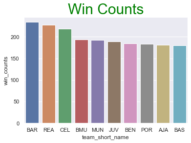

```python
bar_plot(df_gb_team[:10],'team_short_name','win_counts','Win Counts')
plt.title('Win Counts',fontsize=30,color="green")
```

### Those are the top teams achieved victories ordered from the highest

### 2.1.3. Interpret the findings

```python
df_gb_team.loc[df_gb_team['team_short_name']=='BAR']
```

|  | team_api_id | team_short_name | team_long_name | buildUpPlaySpeed | buildUpPlayDribbling | buildUpPlayPassing | chanceCreationPassing | chanceCreationCrossing | chanceCreationShooting | defencePressure | defenceAggression | defenceTeamWidth | goal_counts | win_counts | lose_counts |
| --- | --- | --- | --- | --- | --- | --- | --- | --- | --- | --- | --- | --- | --- | --- | --- |
| 0 | 8634 | BAR | FC Barcelona | 35.833333 | 44.071575 | 34.0 | 45.166667 | 33.333333 | 53.000000 | 64.333333 | 54.5 | 66.5 | 849.0 | 234.0 | 27.0 |
| 229 | 9976 | BAR | Bari | 51.166667 | 45.738241 | 49.0 | 48.833333 | 46.833333 | 57.333333 | 48.000000 | 45.5 | 54.0 | 76.0 | 18.0 | 38.0 |

## Answer to Question 1: the most team achieved victories?

[output not shown]

### 2.2. Research Question 2: What team attributes lead the most teams to achieve those victories?

### 2.2.1. Prepare Data Frame

filtering the dataframe by the first top ten teams

```python
df_gb_team[:10]
```

|  | team_api_id | team_short_name | team_long_name | buildUpPlaySpeed | buildUpPlayDribbling | buildUpPlayPassing | chanceCreationPassing | chanceCreationCrossing | chanceCreationShooting | defencePressure | defenceAggression | defenceTeamWidth | goal_counts | win_counts | lose_counts |
| --- | --- | --- | --- | --- | --- | --- | --- | --- | --- | --- | --- | --- | --- | --- | --- |
| 0 | 8634 | BAR | FC Barcelona | 35.833333 | 44.071575 | 34.000000 | 45.166667 | 33.333333 | 53.000000 | 64.333333 | 54.500000 | 66.500000 | 849.0 | 234.0 | 27.0 |
| 1 | 8633 | REA | Real Madrid CF | 50.666667 | 50.904908 | 38.666667 | 67.500000 | 53.833333 | 69.000000 | 52.000000 | 52.166667 | 63.500000 | 843.0 | 228.0 | 40.0 |
| 2 | 9925 | CEL | Celtic | 61.333333 | 49.238241 | 57.333333 | 55.666667 | 60.833333 | 60.833333 | 53.333333 | 54.333333 | 62.166667 | 695.0 | 218.0 | 36.0 |
| 3 | 9823 | BMU | FC Bayern Munich | 48.666667 | 42.071575 | 35.166667 | 38.500000 | 40.666667 | 49.666667 | 57.166667 | 48.833333 | 55.166667 | 653.0 | 193.0 | 35.0 |
| 4 | 10260 | MUN | Manchester United | 51.833333 | 45.071575 | 45.833333 | 50.000000 | 63.166667 | 53.833333 | 45.000000 | 48.000000 | 54.833333 | 582.0 | 192.0 | 55.0 |
| 5 | 9885 | JUV | Juventus | 45.833333 | 46.071575 | 32.833333 | 56.666667 | 60.500000 | 65.666667 | 44.000000 | 57.333333 | 41.166667 | 543.0 | 189.0 | 46.0 |
| 6 | 9772 | BEN | SL Benfica | 59.000000 | 50.738241 | 45.500000 | 63.833333 | 59.000000 | 55.333333 | 54.333333 | 51.500000 | 52.000000 | 568.0 | 185.0 | 27.0 |
| 7 | 9773 | POR | FC Porto | 51.000000 | 49.071575 | 48.666667 | 55.666667 | 66.833333 | 66.166667 | 53.333333 | 50.333333 | 55.333333 | 541.0 | 183.0 | 23.0 |
| 8 | 8593 | AJA | Ajax | 35.166667 | 46.238241 | 33.833333 | 50.666667 | 58.500000 | 49.666667 | 59.833333 | 53.833333 | 54.333333 | 647.0 | 181.0 | 32.0 |
| 9 | 9931 | BAS | FC Basel | 55.000000 | 53.404908 | 44.833333 | 60.833333 | 63.833333 | 52.500000 | 47.666667 | 57.500000 | 54.500000 | 619.0 | 180.0 | 42.0 |

### 2.2.2. Plot graphs

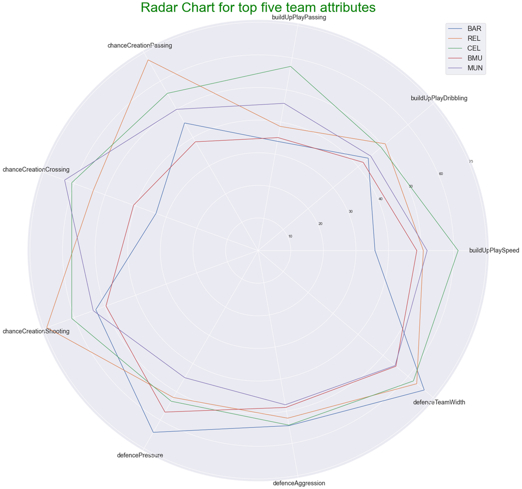

```python
#i WILL CHoose spider chart

#at first I will choose the attributes of teams as the axes
#making an array of attributes to be the axes
labels  =  np.array(['buildUpPlaySpeed','buildUpPlayDribbling','buildUpPlayPassing','chanceCreationPassing','chanceCreationCrossing','chanceCreationShooting','defencePressure','defenceAggression','defenceTeamWidth'])

#grouping the top ten teams only
grouped_df =df_gb_team[:10]

#dropping columns to leave only the columns used in the chart
grouped_df.drop(['team_api_id','team_short_name','team_long_name','win_counts','lose_counts','goal_counts'],axis=1,inplace=True)

#adjusting graph size to be appropriate for comparison
plt.figure(figsize=(25,25))

#making an object of subplot with type polar graph
ax = plt.subplot(111,polar=True)





#making an equal angles between axes using linespace to make an equally distributed array and np.pi to calc the priemeter and len(labels)
#to get how many axes will be made. endpoint equal false to make sure the last point which is the first point will not be included
angles = np.linspace(0,2*np.pi,len(labels),endpoint=False)

#PLOTTING FOR BAR
#getting values for axes for BAR
values = grouped_df.iloc[0]

#making the chart closed using concatenate method it only adds the first value to the end
values=np.concatenate((values,[values[0]]))
angles=np.concatenate((angles,[angles[0]]))

#assigning labels to the axes
plt.xticks(angles[:-1],labels,size=18)

#plotting for BAR values
ax.plot(angles,values,label='BAR')

#plotting for REL
values = grouped_df.iloc[1]
values=np.concatenate((values,[values[0]]))
plt.xticks(angles[:-1],labels,size=18)
ax.plot(angles,values,label= 'REL')

#Plotting for CEL
values = grouped_df.iloc[2]
values=np.concatenate((values,[values[0]]))
plt.xticks(angles[:-1],labels,size=18)
ax.plot(angles,values,label='CEL')

#Plotting for BMU
values =grouped_df.iloc[3]
values=np.concatenate((values,[values[0]]))
plt.xticks(angles[:-1],labels,size=18)
ax.plot(angles,values,label= 'BMU')

#Plotting for MUN
values = grouped_df.iloc[4]
values=np.concatenate((values,[values[0]]))
plt.xticks(angles[:-1],labels,size=18)
ax.plot(angles,values,label='MUN')



#to match the colors with the team names
plt.legend(fontsize=20)
plt.title("Radar Chart for top five team attributes",fontsize=40,color="green",loc='center')
```

### 2.2.3. Interpret the findings

```
we know that BAR and REL are the most teams achieved victories after comparing Their attributes with the rest of the teams it appeared that defence pressure and defence team width are remarkably high for Barcelona. for Real Madrid chance creation shooting and chance creation passing are high for Real Madrid
```

### 2.2.4. Trends

```
charts are in small size in jupyter only but if you download it and figure it will be very clear
```

```python
#list of attributes
x_vars1=['buildUpPlaySpeed','buildUpPlayDribbling','buildUpPlayPassing']
x_vars2=['chanceCreationPassing','chanceCreationCrossing','chanceCreationShooting']
x_vars3=['defencePressure','defenceAggression','defenceTeamWidth']
```

### Win counts

Trying to find the trend in win counts and attributes

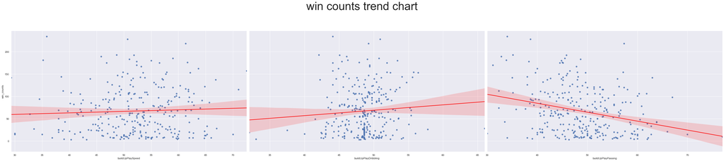

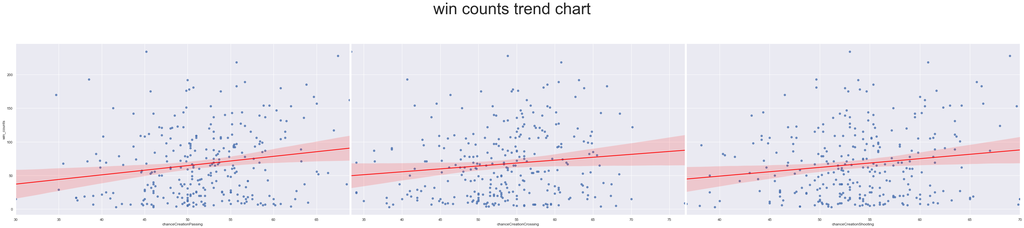

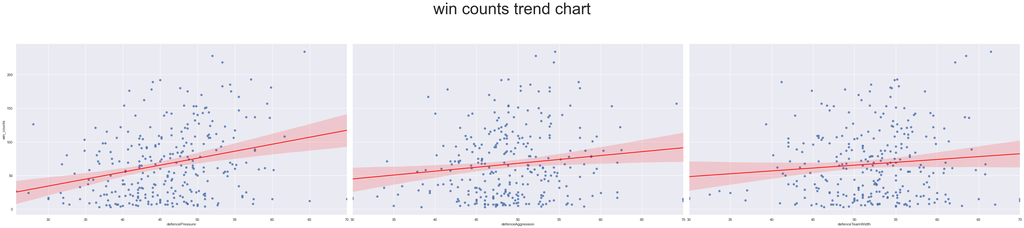

```python
pair_plot(df_gb_team,'win counts trend chart',x_vars1,'win_counts')
pair_plot(df_gb_team,'win counts trend chart',x_vars2,'win_counts')
pair_plot(df_gb_team,'win counts trend chart',x_vars3,'win_counts')
```

it seems that defence pressure and chance creation passing have a high slope while build up play passing has a low slope.

### Lose counts

Trying to find the trend in lose counts and attributes

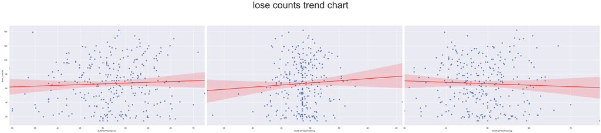

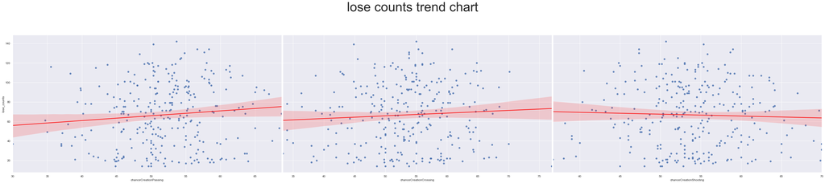

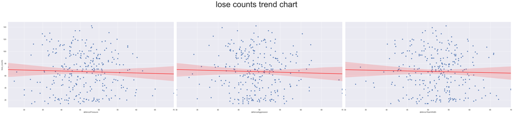

```python
pair_plot(df_gb_team,'lose counts trend chart',x_vars1,'lose_counts')
pair_plot(df_gb_team,'lose counts trend chart',x_vars2,'lose_counts')
pair_plot(df_gb_team,'lose counts trend chart',x_vars3,'lose_counts')
```

```
slopes are almost horizontal
```

### No of goals

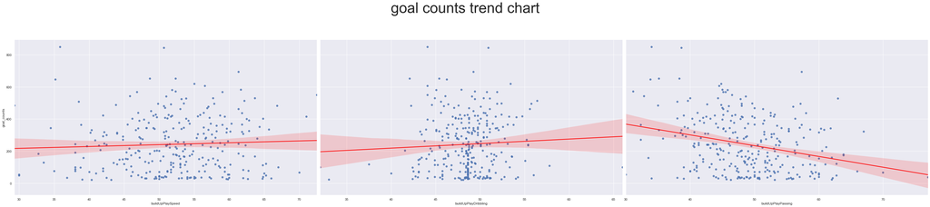

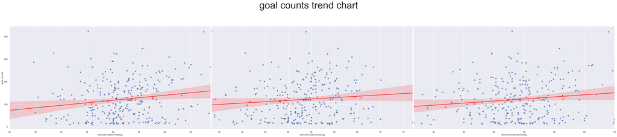

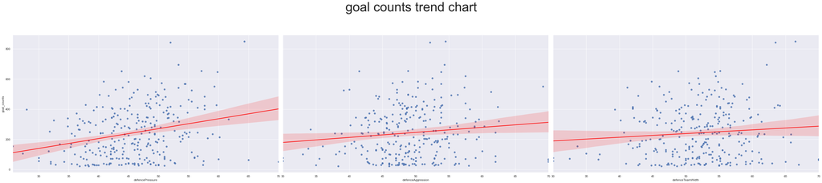

```python
pair_plot(df_gb_team,'goal counts trend chart',x_vars1,'goal_counts')
pair_plot(df_gb_team,'goal counts trend chart',x_vars2,'goal_counts')
pair_plot(df_gb_team,'goal counts trend chart',x_vars3,'goal_counts')
```

```
it shows the same trends as win counts. defence pressure and chance creation passing have a high slope while build up
play passing has very low slope.
```

## Answer to Question 2: the team attributes lead the most teams to achieve those victories?

```
Findings for this question deducted from the plots shows that "Defence Pressure", "Chance creation passing" are the two team attributes that lead to increase team victories, while decreasing the build up play plassing shows that win victories are increased
```

## 4. Conclusions

```
In Conclusion for this case study which is about analyzing European soccer Database from 2008 to 2016 to answer
two questions: The most team achieved most victories over the time period and What are the attributes lead this team to achieve victories.
From the plots, It has been shown that Barcelona -Named BAR on the plots- is the most team achieved victories by 234 Win . Real Madrid - Named REL on the plots - comes after Barcelona by achieving 228 Win.
In analyzing team attributes, It shows that for Barcelona defence pressure and defence team width was remarkably high from other teams so it must lead them to achieved those victories. and for Real Madrid chance creation shooting and chance creation passing was very high.
In analyzing trends of win counts, lose counts, and goal counts, It's found that win counts increases when defence pressure and chance creation passing increases, and when build up play passing decreases
```

### Limitation

[output not shown]